```r
# initial settings
#Note the installation of the forecast packages takes a while
libary_path <- paste(getwd(), "packages",sep="/")
dir.create(libary_path,showWarnings = FALSE)
.libPaths(libary_path)

if(!require(tidyverse)){
    install.packages("tidyverse")
    library(tidyverse)
}
if(!require(repr)){
    install.packages("repr")
    library(repr)
}
if(!require(tree)){
    install.packages("tree")
    library(tree)
}
if(!require(rpart)){
    install.packages("rpart")
    library(rpart)
}
if(!require(rpart.plot)){
    install.packages("rpart.plot")
    library(rpart.plot)
}
if(!require(caret)){
    install.packages("caret")
    library(caret)
}
if(!require(precrec)){
    install.packages("precrec")
    library(precrec)
}
if(!require(e1071)){
    install.packages("e1071")
    library(e1071)
}
if(!require(ISLR)){
    install.packages("ISLR")
    library(ISLR)
}
if(!require(Metrics)){
    install.packages("Metrics")
    library(Metrics)
}
if(!require(RPostgreSQL)){
    install.packages("RPostgreSQL")
    library(RPostgreSQL)
}

#library(tidyverse)
#library(tree)
#library(rpart)
#library(rpart.plot)
#library(caret)

#install.packages('precrec',lib='.', verbose=TRUE)
#library(precrec,lib.loc='.')



#library(tidyverse)
#library(rpart)
#library(rpart.plot)
#library(caret)
#library(ISLR)
#library(Metrics)
#library(RPostgreSQL)






# Plot size depending on your screen resolution to 5 x 3
options(repr.plot.width=9, repr.plot.height=6)
```

# Welcome to Day 2 ML Worshop

### Exercise 1: Build a Regression Tree

For this workshop, we will build a tree based on a continuous response variable. In a regression tree, the prediction at each node is the mean value of the target variable for data points in that node. The measure of disorder is calculated for each node.

```r
str(Carseats)
```

```
'data.frame':	400 obs. of  11 variables:
 $ Sales      : num  9.5 11.22 10.06 7.4 4.15 ...
 $ CompPrice  : num  138 111 113 117 141 124 115 136 132 132 ...
 $ Income     : num  73 48 35 100 64 113 105 81 110 113 ...
 $ Advertising: num  11 16 10 4 3 13 0 15 0 0 ...
 $ Population : num  276 260 269 466 340 501 45 425 108 131 ...
 $ Price      : num  120 83 80 97 128 72 108 120 124 124 ...
 $ ShelveLoc  : Factor w/ 3 levels "Bad","Good","Medium": 1 2 3 3 1 1 3 2 3 3 ...
 $ Age        : num  42 65 59 55 38 78 71 67 76 76 ...
 $ Education  : num  17 10 12 14 13 16 15 10 10 17 ...
 $ Urban      : Factor w/ 2 levels "No","Yes": 2 2 2 2 2 1 2 2 1 1 ...
 $ US         : Factor w/ 2 levels "No","Yes": 2 2 2 2 1 2 1 2 1 2 ...
```

```r
head(Carseats)
```

A data.frame: 6 × 11

|  | Sales <dbl> | CompPrice <dbl> | Income <dbl> | Advertising <dbl> | Population <dbl> | Price <dbl> | ShelveLoc <fct> | Age <dbl> | Education <dbl> | Urban <fct> | US <fct> |
| --- | --- | --- | --- | --- | --- | --- | --- | --- | --- | --- | --- |
| 1 | 9.50 | 138 | 73 | 11 | 276 | 120 | Bad | 42 | 17 | Yes | Yes |
| 2 | 11.22 | 111 | 48 | 16 | 260 | 83 | Good | 65 | 10 | Yes | Yes |
| 3 | 10.06 | 113 | 35 | 10 | 269 | 80 | Medium | 59 | 12 | Yes | Yes |
| 4 | 7.40 | 117 | 100 | 4 | 466 | 97 | Medium | 55 | 14 | Yes | Yes |
| 5 | 4.15 | 141 | 64 | 3 | 340 | 128 | Bad | 38 | 13 | Yes | No |
| 6 | 10.81 | 124 | 113 | 13 | 501 | 72 | Bad | 78 | 16 | No | Yes |

```r
#If you do not have an ID per row, use the following code to create an ID
carseats.df <- Carseats %>%
                    mutate(id = row_number())

#Check IDs
head(carseats.df)

#Create training set
train.df <- carseats.df %>%
                sample_frac(.75)

#Create test set
test.df  <- anti_join(carseats.df, train.df, by = 'id')


train.df <- train.df %>%
    select(-id)

test.df <- test.df %>%
    select(-id)
```

A data.frame: 6 × 12

|  | Sales <dbl> | CompPrice <dbl> | Income <dbl> | Advertising <dbl> | Population <dbl> | Price <dbl> | ShelveLoc <fct> | Age <dbl> | Education <dbl> | Urban <fct> | US <fct> | id <int> |
| --- | --- | --- | --- | --- | --- | --- | --- | --- | --- | --- | --- | --- |
| 1 | 9.50 | 138 | 73 | 11 | 276 | 120 | Bad | 42 | 17 | Yes | Yes | 1 |
| 2 | 11.22 | 111 | 48 | 16 | 260 | 83 | Good | 65 | 10 | Yes | Yes | 2 |
| 3 | 10.06 | 113 | 35 | 10 | 269 | 80 | Medium | 59 | 12 | Yes | Yes | 3 |
| 4 | 7.40 | 117 | 100 | 4 | 466 | 97 | Medium | 55 | 14 | Yes | Yes | 4 |
| 5 | 4.15 | 141 | 64 | 3 | 340 | 128 | Bad | 38 | 13 | Yes | No | 5 |
| 6 | 10.81 | 124 | 113 | 13 | 501 | 72 | Bad | 78 | 16 | No | Yes | 6 |

```r
head(train.df)
```

A data.frame: 6 × 11

|  | Sales <dbl> | CompPrice <dbl> | Income <dbl> | Advertising <dbl> | Population <dbl> | Price <dbl> | ShelveLoc <fct> | Age <dbl> | Education <dbl> | Urban <fct> | US <fct> |
| --- | --- | --- | --- | --- | --- | --- | --- | --- | --- | --- | --- |
| 167 | 6.71 | 119 | 67 | 17 | 151 | 137 | Medium | 55 | 11 | Yes | Yes |
| 93 | 4.53 | 114 | 113 | 0 | 97 | 125 | Medium | 29 | 12 | Yes | No |
| 371 | 7.68 | 126 | 41 | 22 | 403 | 119 | Bad | 42 | 12 | Yes | Yes |
| 42 | 7.96 | 157 | 53 | 0 | 403 | 124 | Bad | 58 | 16 | Yes | No |
| 358 | 13.36 | 103 | 73 | 3 | 276 | 72 | Medium | 34 | 15 | Yes | Yes |
| 88 | 11.70 | 131 | 67 | 7 | 272 | 126 | Good | 54 | 16 | No | Yes |

```r
head(test.df)
```

A data.frame: 6 × 11

|  | Sales <dbl> | CompPrice <dbl> | Income <dbl> | Advertising <dbl> | Population <dbl> | Price <dbl> | ShelveLoc <fct> | Age <dbl> | Education <dbl> | Urban <fct> | US <fct> |
| --- | --- | --- | --- | --- | --- | --- | --- | --- | --- | --- | --- |
| 8 | 11.85 | 136 | 81 | 15 | 425 | 120 | Good | 67 | 10 | Yes | Yes |
| 16 | 8.71 | 149 | 95 | 5 | 400 | 144 | Medium | 76 | 18 | No | No |
| 20 | 8.73 | 129 | 76 | 16 | 58 | 121 | Medium | 69 | 12 | Yes | Yes |
| 22 | 12.13 | 134 | 29 | 12 | 239 | 109 | Good | 62 | 18 | No | Yes |
| 23 | 5.08 | 128 | 46 | 6 | 497 | 138 | Medium | 42 | 13 | Yes | No |
| 25 | 10.14 | 145 | 119 | 16 | 294 | 113 | Bad | 42 | 12 | Yes | Yes |

Let's now build a tree explaining `Sales` using the training set

```r
tree_model<-rpart(Sales ~ .,
                 data=train.df,
                 method="anova",
                 control=rpart.control( maxdepth = 2, # max depth
                                       xval = 1)) # to use all samples for the first try out
tree_model
```

```
n= 300

node), split, n, deviance, yval
      * denotes terminal node

1) root 300 2390.16500  7.377500
  2) ShelveLoc=Bad,Medium 242 1445.48000  6.693182
    4) Price>=105.5 156  674.38630  5.817244 *
    5) Price< 105.5 86  434.28080  8.282093 *
  3) ShelveLoc=Good 58  358.51340 10.232760
    6) Price>=107.5 36  166.90950  9.090278 *
    7) Price< 107.5 22   67.72259 12.102270 *
```

```r
printcp(tree_model)
```

```
Regression tree:
rpart(formula = Sales ~ ., data = train.df, method = "anova",
    control = rpart.control(maxdepth = 2, xval = 1))

Variables actually used in tree construction:
[1] Price     ShelveLoc

Root node error: 2390.2/300 = 7.9672

n= 300

       CP nsplit rel error
1 0.24524      0   1.00000
2 0.14092      1   0.75476
3 0.05183      2   0.61384
4 0.01000      3   0.56201
```

Let's plot the tree, this is one of the few times we make use of the R-base graphics

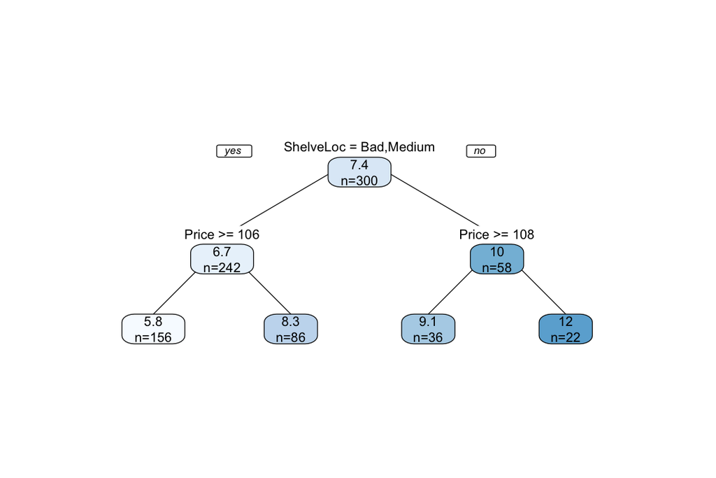

```r
rpart.plot(tree_model,
           fallen.leaves = FALSE, # to position the leaf nodes at the bottom of the graph changes this to TRUE
           type  = 1, # 1 Label all nodes, not just leaves.
           extra = 1, # 1 Display the number of observations that fall in the node
           split.font = 1, # Font for the split labels. 1=normal 2=bold
           varlen = -10) # Length of variable names in text at the splits (and, for class responses, the class in the node label). Default -8, meaning truncate to eight characters.
```

Evaluate its performance on the test-set:

```r
treePred.reg <- predict(tree_model, newdata = test.df)

head(treePred.reg)
```

**8**

9.09027777777778

**16**

5.81724358974359

**20**

5.81724358974359

**22**

9.09027777777778

**23**

5.81724358974359

**25**

5.81724358974359

Lets calculate the RMSE:

```r
rmse(test.df$Sales, treePred.reg)
```

2.37243115858012

Create a new data frame with predicted and actual values and create a scatter plot. Fix the axis to have the same dimensions:

A data.frame: 6 × 2

|  | actual <dbl> | predicted <dbl> |
| --- | --- | --- |
| 8 | 11.85 | 9.090278 |
| 16 | 8.71 | 5.817244 |
| 20 | 8.73 | 5.817244 |
| 22 | 12.13 | 9.090278 |
| 23 | 5.08 | 5.817244 |
| 25 | 10.14 | 5.817244 |

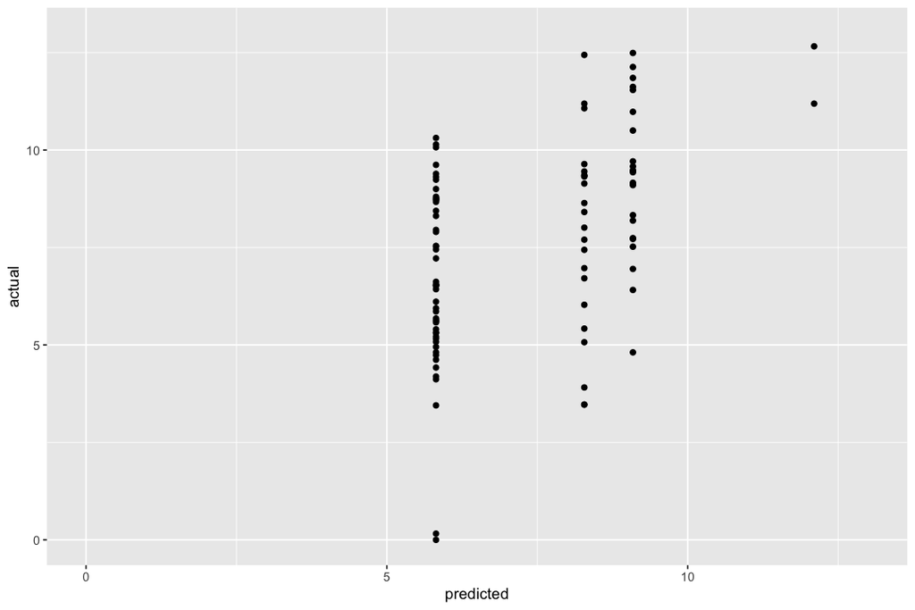

```r
### BEGIN SOLUTION
tmp.df <- data.frame(actual=test.df$Sales,predicted=treePred.reg)
head(tmp.df)

ggplot(data=tmp.df,aes(x=predicted,
                       y=actual)) +
        geom_point() +
        ylim(0,13) +
        xlim(0,13)

### END SOLUTION
```

If you look at this graph, you will see that there is not much variation in the predicted values. Change the parameters to decrease RMSE and make the graph look better. For this write nested for loops to perform a grid search across parameters on the training set.

```r
minsplit <- 1:2
minbucket <- 1:2
maxdepth <- 1:5

n<- length(minsplit)*length(minbucket)*length(maxdepth)

gridsearch.df <- data.frame(minsplit = numeric(n),
                            minbucket = numeric(n),
                            maxdepth = numeric(n),
                            rmse = numeric(n))

### BEGIN SOLUTION
i <- 1
for(split in minsplit){
    for(bucket in minbucket){
        for(depth in maxdepth) {
            tmp_tree<-rpart(Sales ~ .,
                         data=train.df,
                         method="anova",
                         control=rpart.control(
                             minsplit = split,
                             minbucket = bucket,
                             maxdepth = depth,
                             xval = 1))

            tmp.reg <- predict(tmp_tree, newdata = test.df)
            gridsearch.df$minsplit[i]  <- split
            gridsearch.df$minbucket[i] <- bucket
            gridsearch.df$maxdepth[i]  <- depth
            gridsearch.df$rmse[i]      <- rmse(test.df$Sales, tmp.reg)
            i <- i + 1
        }
    }
}
### END SOLUTION
```

```r
gridsearch.df %>%
    arrange(rmse)
```

A data.frame: 20 × 4

| minsplit <dbl> | minbucket <dbl> | maxdepth <dbl> | rmse <dbl> |
| --- | --- | --- | --- |
| 1 | 1 | 5 | 2.218818 |
| 1 | 2 | 5 | 2.218818 |
| 2 | 1 | 5 | 2.218818 |
| 2 | 2 | 5 | 2.218818 |
| 1 | 1 | 3 | 2.277323 |
| 1 | 2 | 3 | 2.277323 |
| 2 | 1 | 3 | 2.277323 |
| 2 | 2 | 3 | 2.277323 |
| 1 | 1 | 4 | 2.279076 |
| 1 | 2 | 4 | 2.279076 |
| 2 | 1 | 4 | 2.279076 |
| 2 | 2 | 4 | 2.279076 |
| 1 | 1 | 2 | 2.372431 |
| 1 | 2 | 2 | 2.372431 |
| 2 | 1 | 2 | 2.372431 |
| 2 | 2 | 2 | 2.372431 |
| 1 | 1 | 1 | 2.413821 |
| 1 | 2 | 1 | 2.413821 |
| 2 | 1 | 1 | 2.413821 |
| 2 | 2 | 1 | 2.413821 |

Pick the best configuration, re-run the build of a tree and provide a scatter plot. What do you see now ?

A data.frame: 6 × 2

|  | actual <dbl> | predicted <dbl> |
| --- | --- | --- |
| 8 | 11.85 | 7.857500 |
| 16 | 8.71 | 5.797143 |
| 20 | 8.73 | 6.617778 |
| 22 | 12.13 | 7.857500 |
| 23 | 5.08 | 8.068571 |
| 25 | 10.14 | 5.287941 |

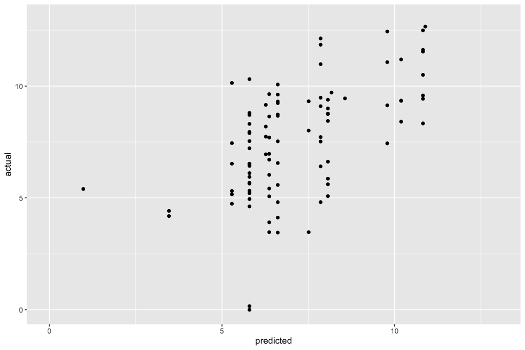

```r
### BEGIN SOLUTION
tmp_tree<-rpart(Sales ~ .,
                         data=train.df,
                         method="anova",
                         control=rpart.control(
                             minsplit = 1,
                             minbucket = 1,
                             maxdepth = 5,
                             xval = 1))

tmp.reg <- predict(tmp_tree, newdata = test.df)


tmp.df <- data.frame(actual=test.df$Sales,predicted=tmp.reg)
head(tmp.df)

ggplot(data=tmp.df,aes(x=predicted,
                       y=actual)) +
        geom_point() +
        ylim(0,13) +
        xlim(0,13)


### END SOLUTION
```

### Exercise 2: Flights from JFK

Load the file `public.flight_delay_workshop`. You will see that the first columns represent the arrival delay in minutes. Build a predictive model that will predict the delay as accurate as possible for December, with using training data up to November. What RMSE can you achieve ? What could you do to achieve a higher value ?

A data.frame: 6 × 9

|  | arrdelay <dbl> | carrier <chr> | dayofweek <int> | month <int> | departurehour <int> | destination <chr> | origin <chr> | weatherdelay <int> | airtime <dbl> |
| --- | --- | --- | --- | --- | --- | --- | --- | --- | --- |
| 1 | 14 | MQ | 5 | 2 | 16 | RDU | JFK | 0 | 82 |
| 2 | 35 | MQ | 1 | 2 | 17 | RDU | JFK | 0 | 74 |
| 3 | 56 | MQ | 7 | 2 | 17 | RDU | JFK | 0 | 79 |
| 4 | 92 | MQ | 3 | 2 | 18 | RDU | JFK | 0 | 88 |
| 5 | 4 | MQ | 6 | 2 | 17 | RDU | JFK | 0 | 70 |
| 6 | 36 | MQ | 6 | 2 | 17 | RDU | JFK | 0 | 70 |

A data.frame: 6 × 7

|  | arrdelay <dbl> | carrier <chr> | dayofweek <int> | departurehour <int> | destination <chr> | weatherdelay <int> | airtime <dbl> |
| --- | --- | --- | --- | --- | --- | --- | --- |
| 1 | 14 | MQ | 5 | 16 | RDU | 0 | 82 |
| 2 | 35 | MQ | 1 | 17 | RDU | 0 | 74 |
| 3 | 56 | MQ | 7 | 17 | RDU | 0 | 79 |
| 4 | 92 | MQ | 3 | 18 | RDU | 0 | 88 |
| 5 | 4 | MQ | 6 | 17 | RDU | 0 | 70 |
| 6 | 36 | MQ | 6 | 17 | RDU | 0 | 70 |

A data.frame: 6 × 7

|  | arrdelay <dbl> | carrier <chr> | dayofweek <int> | departurehour <int> | destination <chr> | weatherdelay <int> | airtime <dbl> |
| --- | --- | --- | --- | --- | --- | --- | --- |
| 1 | 172 | YV | 1 | 22 | IAD | 0 | 47 |
| 2 | 66 | YV | 1 | 23 | IAD | 0 | 47 |
| 3 | 35 | YV | 3 | 20 | IAD | 0 | 45 |
| 4 | 19 | YV | 4 | 19 | IAD | 0 | 77 |
| 5 | 226 | YV | 7 | 23 | IAD | 0 | 46 |
| 6 | 46 | YV | 7 | 22 | IAD | 0 | 50 |

```
n= 26246

node), split, n, deviance, yval
      * denotes terminal node

 1) root 26246 130278300  64.73520
   2) departurehour>=4.5 25541 115090500  61.98669
     4) departurehour< 17.5 14270  45373550  49.03392 *
     5) departurehour>=17.5 11271  64291610  78.38595
      10) weatherdelay< 0.5 10244  52301340  73.99043
        20) carrier=B6,DL,EV,MQ,OH,UA,US 9051  41502180  69.74268
          40) departurehour< 21.5 6344  25772050  63.98108 *
          41) departurehour>=21.5 2707  15025990  83.24529
            82) destination=ACK,ALB,BDL,BOS,BQN,BTV,BUF,BWI,CLT,CMH,DCA,IAD,IND,ORF,PSE,PVD,PWM,RDU,RIC,ROC,SYR 1579   4582072  55.90310 *
            83) destination=ATL,AUS,BNA,BUR,CLE,CVG,DEN,DFW,DTW,FLL,HOU,JAX,LAS,LAX,LGB,MCO,MIA,MSP,MSY,OAK,ONT,ORD,PBI,PDX,PHL,PHX,PIT,RSW,SAN,SEA,SFO,SJU,SLC,SMF,TPA 1128   7611040 121.51950 *
        21) carrier=AA,CO,NW,YV 1193   9396851 106.21710
          42) departurehour< 21.5 1079   6858792  95.02317 *
          43) departurehour>=21.5 114   1123170 212.16670 *
      11) weatherdelay>=0.5 1027   9818162 122.22980 *
   3) departurehour< 4.5 705   8004853 164.30920
     6) destination=ACK,ALB,BDL,BOS,BQN,BTV,BUF,CLT,DCA,IAD,ORF,PSE,PWM,RIC,SJU,SYR 421   2743132 114.01900 *
     7) destination=ATL,AUS,BUR,CLE,CVG,DEN,FLL,HOU,JAX,LAS,LAX,MCO,MIA,MSP,MSY,ORD,PBI,PDX,PHX,PIT,PVD,RDU,ROC,RSW,SAN,SEA,SFO,SLC,SMF,TPA 284   2618582 238.85920 *
```

A data.frame: 6 × 2

|  | actual <dbl> | predicted <dbl> |
| --- | --- | --- |
| 1 | 172 | 212.16667 |
| 2 | 66 | 212.16667 |
| 3 | 35 | 95.02317 |
| 4 | 19 | 95.02317 |
| 5 | 226 | 212.16667 |
| 6 | 46 | 212.16667 |

64.1981616416331

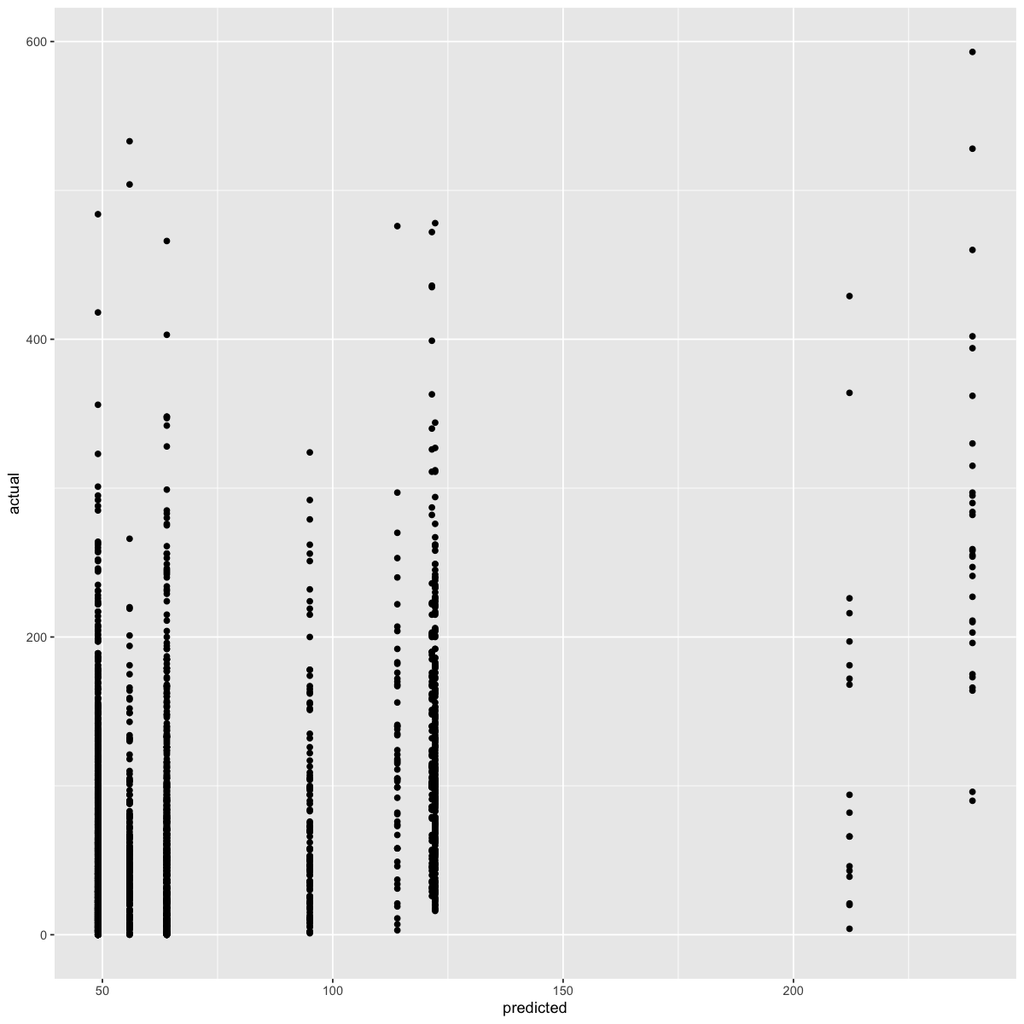

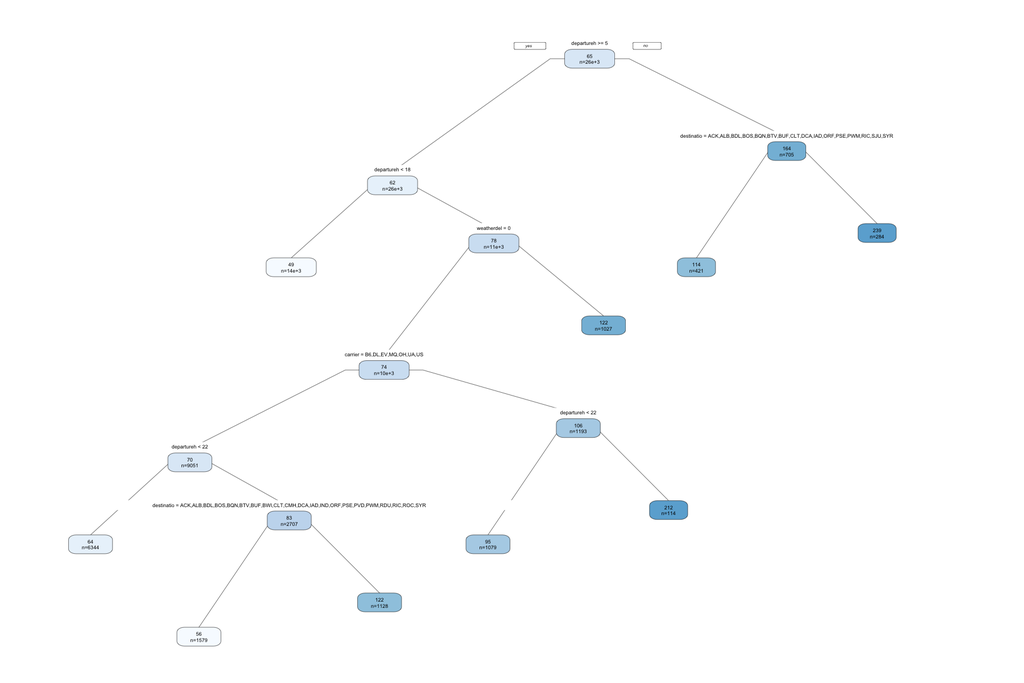

```r
### BEGIN SOLUTION

auth <- read.csv('auth.csv', header = TRUE) # never save a password in a notebook directly
drv <- dbDriver('PostgreSQL')
# you need to close the connection
con <- dbConnect(
  drv,
  host = "118.138.239.213",
  dbname = "summer2022",
  user = toString(auth$username),
  password = toString(auth$password)
)

query <- "
SELECT
    *
FROM
    public.flight_delay_workshop where destination != 'EGE';
"

flights.df <- dbGetQuery(con, query)
head(flights.df)



train.df <- flights.df %>%
                filter(month<12) %>%
                select(arrdelay, carrier, dayofweek, departurehour, destination, weatherdelay, airtime )

head(train.df)

test.df <- flights.df %>%
                filter(month==12) %>%
                select(arrdelay, carrier, dayofweek, departurehour, destination, weatherdelay, airtime )


head(test.df)



tmp_tree<-rpart(arrdelay ~ .,
                         data=train.df,
                         method="anova",
                         control=rpart.control(
                             xval = 10))
tmp_tree

tmp.reg <- predict(tmp_tree, newdata = test.df)


tmp.df <- data.frame(actual=test.df$arrdelay,predicted=tmp.reg)
head(tmp.df)

ggplot(data=tmp.df,aes(x=predicted,
                       y=actual)) +
        geom_point()


rmse(test.df$arrdelay, tmp.reg)

options(repr.plot.width=15, repr.plot.height=10)

rpart.plot(tmp_tree,
           fallen.leaves = FALSE, # to position the leaf nodes at the bottom of the graph changes this to TRUE
           type  = 1, # 1 Label all nodes, not just leaves.
           extra = 1, # 1 Display the number of observations that fall in the node
           split.font = 1, # Font for the split labels. 1=normal 2=bold
           varlen = -10) # Length of variable names in text at the splits (and, for class responses, the class in the node label). Default -8, meaning truncate to eight characters.


### END SOLUTION
```